# Homework 2 Part 2

### Part a

```python
import numpy as np
import pandas as pd
```

```python
#reading in the csv file
bankTable = pd.read_csv("/Users/danielobrien/bank_data.csv", index_col=0)
bankTable.shape
```

```
(600, 11)
```

```python
bankTable.head()
```

| id | age | income | children | gender | region | married | car | savings_acct | current_acct | mortgage | pep |
| --- | --- | --- | --- | --- | --- | --- | --- | --- | --- | --- | --- |
| ID12101 | 48 | 17546.0 | 1 | FEMALE | INNER_CITY | NO | NO | NO | NO | NO | YES |
| ID12102 | 40 | 30085.1 | 3 | MALE | TOWN | YES | YES | NO | YES | YES | NO |
| ID12103 | 51 | 16575.4 | 0 | FEMALE | INNER_CITY | YES | YES | YES | YES | NO | NO |
| ID12104 | 23 | 20375.4 | 3 | FEMALE | TOWN | YES | NO | NO | YES | NO | NO |
| ID12105 | 57 | 50576.3 | 0 | FEMALE | RURAL | YES | NO | YES | NO | NO | NO |

```python
BT_target = bankTable.pep
BT_target.head()
```

```
id
ID12101    YES
ID12102     NO
ID12103     NO
ID12104     NO
ID12105     NO
Name: pep, dtype: object
```

```python
BT_records = bankTable[['age','income','children','gender','region','married','car','savings_acct','current_acct','mortgage']]
BT_records.head()
```

| id | age | income | children | gender | region | married | car | savings_acct | current_acct | mortgage |
| --- | --- | --- | --- | --- | --- | --- | --- | --- | --- | --- |
| ID12101 | 48 | 17546.0 | 1 | FEMALE | INNER_CITY | NO | NO | NO | NO | NO |
| ID12102 | 40 | 30085.1 | 3 | MALE | TOWN | YES | YES | NO | YES | YES |
| ID12103 | 51 | 16575.4 | 0 | FEMALE | INNER_CITY | YES | YES | YES | YES | NO |
| ID12104 | 23 | 20375.4 | 3 | FEMALE | TOWN | YES | NO | NO | YES | NO |
| ID12105 | 57 | 50576.3 | 0 | FEMALE | RURAL | YES | NO | YES | NO | NO |

```python
BT_matrix = pd.get_dummies(BT_records[['age', 'income','gender','region','married','car','savings_acct','current_acct','mortgage']])
BT_matrix[:10]
```

| id | age | income | gender_FEMALE | gender_MALE | region_INNER_CITY | region_RURAL | region_SUBURBAN | region_TOWN | married_NO | married_YES | car_NO | car_YES | savings_acct_NO | savings_acct_YES | current_acct_NO | current_acct_YES | mortgage_NO | mortgage_YES |
| --- | --- | --- | --- | --- | --- | --- | --- | --- | --- | --- | --- | --- | --- | --- | --- | --- | --- | --- |
| ID12101 | 48 | 17546.00 | 1 | 0 | 1 | 0 | 0 | 0 | 1 | 0 | 1 | 0 | 1 | 0 | 1 | 0 | 1 | 0 |
| ID12102 | 40 | 30085.10 | 0 | 1 | 0 | 0 | 0 | 1 | 0 | 1 | 0 | 1 | 1 | 0 | 0 | 1 | 0 | 1 |
| ID12103 | 51 | 16575.40 | 1 | 0 | 1 | 0 | 0 | 0 | 0 | 1 | 0 | 1 | 0 | 1 | 0 | 1 | 1 | 0 |
| ID12104 | 23 | 20375.40 | 1 | 0 | 0 | 0 | 0 | 1 | 0 | 1 | 1 | 0 | 1 | 0 | 0 | 1 | 1 | 0 |
| ID12105 | 57 | 50576.30 | 1 | 0 | 0 | 1 | 0 | 0 | 0 | 1 | 1 | 0 | 0 | 1 | 1 | 0 | 1 | 0 |
| ID12106 | 57 | 37869.60 | 1 | 0 | 0 | 0 | 0 | 1 | 0 | 1 | 1 | 0 | 0 | 1 | 0 | 1 | 1 | 0 |
| ID12107 | 22 | 8877.07 | 0 | 1 | 0 | 1 | 0 | 0 | 1 | 0 | 1 | 0 | 1 | 0 | 0 | 1 | 1 | 0 |
| ID12108 | 58 | 24946.60 | 0 | 1 | 0 | 0 | 0 | 1 | 0 | 1 | 0 | 1 | 0 | 1 | 0 | 1 | 1 | 0 |
| ID12109 | 37 | 25304.30 | 1 | 0 | 0 | 0 | 1 | 0 | 0 | 1 | 0 | 1 | 1 | 0 | 1 | 0 | 1 | 0 |
| ID12110 | 54 | 24212.10 | 0 | 1 | 0 | 0 | 0 | 1 | 0 | 1 | 0 | 1 | 0 | 1 | 0 | 1 | 1 | 0 |

```python
from sklearn.model_selection import train_test_split
bt_train, bt_test, bt_target_train, bt_target_test = train_test_split(BT_matrix, BT_target, test_size=0.2, random_state=33)

print (bt_test.shape)
```

```
(120, 18)
```

```python
bt_train.shape
```

```
(480, 18)
```

### Part b

```python
from sklearn import preprocessing
```

```python
min_max_scaler = preprocessing.MinMaxScaler().fit(bt_train)
bt_train_norm = min_max_scaler.transform(bt_train)
bt_test_norm = min_max_scaler.transform(bt_test)
```

```python
np.set_printoptions(precision=2, linewidth=80, suppress=True)
bt_train_norm[0:5]
```

```
array([[0.57, 0.46, 1.  , 0.  , 1.  , 0.  , 0.  , 0.  , 0.  , 1.  , 0.  ,
        1.  , 0.  , 1.  , 0.  , 1.  , 1.  , 0.  ],
       [0.8 , 0.78, 1.  , 0.  , 0.  , 1.  , 0.  , 0.  , 0.  , 1.  , 1.  ,
        0.  , 0.  , 1.  , 1.  , 0.  , 1.  , 0.  ],
       [0.14, 0.16, 1.  , 0.  , 1.  , 0.  , 0.  , 0.  , 0.  , 1.  , 1.  ,
        0.  , 0.  , 1.  , 0.  , 1.  , 1.  , 0.  ],
       [0.35, 0.18, 0.  , 1.  , 1.  , 0.  , 0.  , 0.  , 0.  , 1.  , 1.  ,
        0.  , 0.  , 1.  , 0.  , 1.  , 1.  , 0.  ],
       [0.33, 0.18, 1.  , 0.  , 0.  , 0.  , 0.  , 1.  , 0.  , 1.  , 0.  ,
        1.  , 0.  , 1.  , 1.  , 0.  , 0.  , 1.  ]])
```

```python
bt_test_norm[0:5]
```

```
array([[0.29, 0.12, 1.  , 0.  , 0.  , 0.  , 0.  , 1.  , 0.  , 1.  , 0.  ,
        1.  , 0.  , 1.  , 0.  , 1.  , 0.  , 1.  ],
       [0.84, 0.41, 1.  , 0.  , 1.  , 0.  , 0.  , 0.  , 1.  , 0.  , 0.  ,
        1.  , 1.  , 0.  , 0.  , 1.  , 1.  , 0.  ],
       [0.88, 0.62, 0.  , 1.  , 0.  , 1.  , 0.  , 0.  , 0.  , 1.  , 1.  ,
        0.  , 0.  , 1.  , 0.  , 1.  , 0.  , 1.  ],
       [0.71, 0.75, 0.  , 1.  , 0.  , 1.  , 0.  , 0.  , 0.  , 1.  , 0.  ,
        1.  , 0.  , 1.  , 1.  , 0.  , 1.  , 0.  ],
       [0.96, 0.56, 0.  , 1.  , 1.  , 0.  , 0.  , 0.  , 0.  , 1.  , 0.  ,
        1.  , 0.  , 1.  , 1.  , 0.  , 0.  , 1.  ]])
```

```python
from sklearn import neighbors
```

```python
n_neighbors = 5

knnclf = neighbors.KNeighborsClassifier(n_neighbors, weights='distance')
knnclf.fit(bt_train_norm, bt_target_train)
```

```
KNeighborsClassifier(weights='distance')
```

```python
knnpreds_test = knnclf.predict(bt_test_norm)
```

```python
print (knnpreds_test)
```

```
['YES' 'YES' 'NO' 'NO' 'NO' 'YES' 'NO' 'NO' 'NO' 'YES' 'NO' 'NO' 'NO' 'NO'
 'YES' 'NO' 'YES' 'NO' 'YES' 'NO' 'YES' 'YES' 'NO' 'NO' 'YES' 'YES' 'NO' 'NO'
 'NO' 'YES' 'NO' 'NO' 'NO' 'YES' 'NO' 'YES' 'YES' 'YES' 'NO' 'NO' 'NO' 'NO'
 'YES' 'NO' 'YES' 'NO' 'YES' 'YES' 'NO' 'YES' 'YES' 'YES' 'NO' 'NO' 'YES' 'YES'
 'NO' 'NO' 'NO' 'NO' 'NO' 'NO' 'YES' 'NO' 'NO' 'NO' 'NO' 'NO' 'NO' 'YES' 'NO'
 'NO' 'YES' 'NO' 'NO' 'NO' 'YES' 'YES' 'YES' 'NO' 'YES' 'YES' 'NO' 'YES' 'YES'
 'NO' 'YES' 'YES' 'NO' 'YES' 'NO' 'NO' 'NO' 'NO' 'NO' 'NO' 'YES' 'NO' 'NO' 'NO'
 'NO' 'NO' 'NO' 'YES' 'NO' 'NO' 'NO' 'NO' 'YES' 'NO' 'YES' 'NO' 'NO' 'YES' 'NO'
 'YES' 'NO' 'NO' 'NO' 'NO']
```

```python
from sklearn.metrics import classification_report
```

```python
print(classification_report(bt_target_test, knnpreds_test))
```

```
              precision    recall  f1-score   support

          NO       0.59      0.68      0.63        66
         YES       0.52      0.43      0.47        54

    accuracy                           0.57       120
   macro avg       0.56      0.55      0.55       120
weighted avg       0.56      0.57      0.56       120
```

```python
from sklearn.metrics import confusion_matrix
```

```python
knncm = confusion_matrix(bt_target_test, knnpreds_test)
print (knncm)
```

```
[[45 21]
 [31 23]]
```

```python
print (knnclf.score(bt_train_norm, bt_target_train))
```

```
1.0
```

```python
print (knnclf.score(bt_test_norm, bt_target_test))
```

```
0.5666666666666667
```

```python
import pylab as plt
%matplotlib inline
plt.matshow(knncm)
plt.title('Confusion matrix')
plt.colorbar()
plt.ylabel('Actual')
plt.xlabel('Predicted')
plt.show()
```

[output not shown]

### With 1 Neighbor

```python
n_neighbors = 1

knnclf = neighbors.KNeighborsClassifier(n_neighbors, weights='distance')
knnclf.fit(bt_train_norm, bt_target_train)
```

```
KNeighborsClassifier(n_neighbors=1, weights='distance')
```

```python
knnpreds_test = knnclf.predict(bt_test_norm)
```

```python
print (knnpreds_test)
```

```
['YES' 'YES' 'NO' 'YES' 'NO' 'YES' 'NO' 'NO' 'NO' 'YES' 'NO' 'NO' 'NO' 'NO'
 'YES' 'NO' 'YES' 'YES' 'YES' 'NO' 'YES' 'YES' 'NO' 'NO' 'YES' 'YES' 'NO' 'NO'
 'NO' 'NO' 'NO' 'NO' 'NO' 'YES' 'NO' 'NO' 'NO' 'YES' 'NO' 'NO' 'NO' 'NO' 'YES'
 'NO' 'YES' 'NO' 'YES' 'YES' 'NO' 'YES' 'NO' 'YES' 'NO' 'NO' 'YES' 'YES' 'NO'
 'NO' 'NO' 'NO' 'YES' 'NO' 'YES' 'NO' 'NO' 'NO' 'NO' 'NO' 'NO' 'YES' 'YES' 'NO'
 'YES' 'NO' 'NO' 'NO' 'YES' 'YES' 'YES' 'NO' 'YES' 'YES' 'NO' 'YES' 'YES' 'NO'
 'YES' 'YES' 'NO' 'YES' 'NO' 'NO' 'NO' 'NO' 'NO' 'NO' 'YES' 'NO' 'NO' 'YES'
 'NO' 'YES' 'YES' 'YES' 'NO' 'NO' 'NO' 'NO' 'YES' 'NO' 'YES' 'NO' 'NO' 'YES'
 'YES' 'YES' 'NO' 'NO' 'NO' 'NO']
```

```python
print(classification_report(bt_target_test, knnpreds_test))
```

```
              precision    recall  f1-score   support

          NO       0.58      0.64      0.61        66
         YES       0.50      0.44      0.47        54

    accuracy                           0.55       120
   macro avg       0.54      0.54      0.54       120
weighted avg       0.55      0.55      0.55       120
```

```python
knncm = confusion_matrix(bt_target_test, knnpreds_test)
print (knncm)
```

```
[[42 24]
 [30 24]]
```

```python
print (knnclf.score(bt_train_norm, bt_target_train))
```

```
1.0
```

```python
print (knnclf.score(bt_test_norm, bt_target_test))
```

```
0.55
```

```python
import pylab as plt
%matplotlib inline
plt.matshow(knncm)
plt.title('Confusion matrix')
plt.colorbar()
plt.ylabel('Actual')
plt.xlabel('Predicted')
plt.show()
```

[output not shown]

#### 1 neighbor no weights

```python
n_neighbors = 1

knnclf = neighbors.KNeighborsClassifier(n_neighbors)
knnclf.fit(bt_train_norm, bt_target_train)
knnpreds_test = knnclf.predict(bt_test_norm)
print(classification_report(bt_target_test, knnpreds_test))
knncm = confusion_matrix(bt_target_test, knnpreds_test)
print (knncm)
print (knnclf.score(bt_train_norm, bt_target_train))
print (knnclf.score(bt_test_norm, bt_target_test))
```

```
              precision    recall  f1-score   support

          NO       0.58      0.64      0.61        66
         YES       0.50      0.44      0.47        54

    accuracy                           0.55       120
   macro avg       0.54      0.54      0.54       120
weighted avg       0.55      0.55      0.55       120

[[42 24]
 [30 24]]
1.0
0.55
```

```python
import pylab as plt
%matplotlib inline
plt.matshow(knncm)
plt.title('Confusion matrix')
plt.colorbar()
plt.ylabel('Actual')
plt.xlabel('Predicted')
plt.show()
```

[output not shown]

### With 2 Neighbors

```python
n_neighbors = 2

knnclf = neighbors.KNeighborsClassifier(n_neighbors, weights='distance')
knnclf.fit(bt_train_norm, bt_target_train)
```

```
KNeighborsClassifier(n_neighbors=2, weights='distance')
```

```python
knnpreds_test = knnclf.predict(bt_test_norm)
```

```python
print(classification_report(bt_target_test, knnpreds_test))
```

```
              precision    recall  f1-score   support

          NO       0.58      0.64      0.61        66
         YES       0.50      0.44      0.47        54

    accuracy                           0.55       120
   macro avg       0.54      0.54      0.54       120
weighted avg       0.55      0.55      0.55       120
```

```python
knncm = confusion_matrix(bt_target_test, knnpreds_test)
print (knncm)
```

```
[[42 24]
 [30 24]]
```

```python
print (knnclf.score(bt_train_norm, bt_target_train))
```

```
1.0
```

```python
print (knnclf.score(bt_test_norm, bt_target_test))
```

```
0.55
```

```python
import pylab as plt
%matplotlib inline
plt.matshow(knncm)
plt.title('Confusion matrix')
plt.colorbar()
plt.ylabel('Actual')
plt.xlabel('Predicted')
plt.show()
```

[output not shown]

#### 2 Neighbors no weights

```python
n_neighbors = 2

knnclf = neighbors.KNeighborsClassifier(n_neighbors)
knnclf.fit(bt_train_norm, bt_target_train)
knnpreds_test = knnclf.predict(bt_test_norm)
print(classification_report(bt_target_test, knnpreds_test))
knncm = confusion_matrix(bt_target_test, knnpreds_test)
print (knncm)
print (knnclf.score(bt_train_norm, bt_target_train))
print (knnclf.score(bt_test_norm, bt_target_test))
```

```
              precision    recall  f1-score   support

          NO       0.58      0.85      0.69        66
         YES       0.57      0.24      0.34        54

    accuracy                           0.57       120
   macro avg       0.57      0.54      0.51       120
weighted avg       0.57      0.57      0.53       120

[[56 10]
 [41 13]]
0.79375
0.575
```

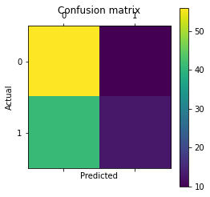

```python
import pylab as plt
%matplotlib inline
plt.matshow(knncm)
plt.title('Confusion matrix')
plt.colorbar()
plt.ylabel('Actual')
plt.xlabel('Predicted')
plt.show()
```

### 3 Neighbors

```python
n_neighbors = 3

knnclf = neighbors.KNeighborsClassifier(n_neighbors, weights='distance')
knnclf.fit(bt_train_norm, bt_target_train)
knnpreds_test = knnclf.predict(bt_test_norm)
print(classification_report(bt_target_test, knnpreds_test))
knncm = confusion_matrix(bt_target_test, knnpreds_test)
print (knncm)
print (knnclf.score(bt_train_norm, bt_target_train))
print (knnclf.score(bt_test_norm, bt_target_test))
```

```
              precision    recall  f1-score   support

          NO       0.57      0.65      0.61        66
         YES       0.49      0.41      0.44        54

    accuracy                           0.54       120
   macro avg       0.53      0.53      0.53       120
weighted avg       0.54      0.54      0.54       120

[[43 23]
 [32 22]]
1.0
0.5416666666666666
```

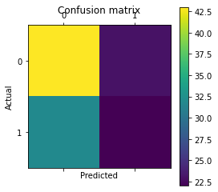

```python
import pylab as plt
%matplotlib inline
plt.matshow(knncm)
plt.title('Confusion matrix')
plt.colorbar()
plt.ylabel('Actual')
plt.xlabel('Predicted')
plt.show()
```

### 3 Neighbors, no weights

```python
n_neighbors = 3

knnclf = neighbors.KNeighborsClassifier(n_neighbors)
knnclf.fit(bt_train_norm, bt_target_train)
knnpreds_test = knnclf.predict(bt_test_norm)
print(classification_report(bt_target_test, knnpreds_test))
knncm = confusion_matrix(bt_target_test, knnpreds_test)
print (knncm)
print (knnclf.score(bt_train_norm, bt_target_train))
print (knnclf.score(bt_test_norm, bt_target_test))
```

```
              precision    recall  f1-score   support

          NO       0.59      0.71      0.65        66
         YES       0.54      0.41      0.46        54

    accuracy                           0.57       120
   macro avg       0.57      0.56      0.56       120
weighted avg       0.57      0.57      0.56       120

[[47 19]
 [32 22]]
0.7729166666666667
0.575
```

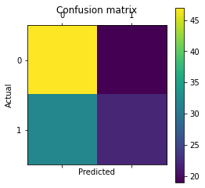

```python
import pylab as plt
%matplotlib inline
plt.matshow(knncm)
plt.title('Confusion matrix')
plt.colorbar()
plt.ylabel('Actual')
plt.xlabel('Predicted')
plt.show()
```

### 4 Neighbors

```python
n_neighbors = 4

knnclf = neighbors.KNeighborsClassifier(n_neighbors, weights='distance')
knnclf.fit(bt_train_norm, bt_target_train)
knnpreds_test = knnclf.predict(bt_test_norm)
print(classification_report(bt_target_test, knnpreds_test))
knncm = confusion_matrix(bt_target_test, knnpreds_test)
print (knncm)
print (knnclf.score(bt_train_norm, bt_target_train))
print (knnclf.score(bt_test_norm, bt_target_test))
```

```
              precision    recall  f1-score   support

          NO       0.59      0.68      0.63        66
         YES       0.52      0.43      0.47        54

    accuracy                           0.57       120
   macro avg       0.56      0.55      0.55       120
weighted avg       0.56      0.57      0.56       120

[[45 21]
 [31 23]]
1.0
0.5666666666666667
```

```python
import pylab as plt
%matplotlib inline
plt.matshow(knncm)
plt.title('Confusion matrix')
plt.colorbar()
plt.ylabel('Actual')
plt.xlabel('Predicted')
plt.show()
```

[output not shown]

### 4 Neighbors, no weights

```python
n_neighbors = 4

knnclf = neighbors.KNeighborsClassifier(n_neighbors)
knnclf.fit(bt_train_norm, bt_target_train)
knnpreds_test = knnclf.predict(bt_test_norm)
print(classification_report(bt_target_test, knnpreds_test))
knncm = confusion_matrix(bt_target_test, knnpreds_test)
print (knncm)
print (knnclf.score(bt_train_norm, bt_target_train))
print (knnclf.score(bt_test_norm, bt_target_test))
```

```
              precision    recall  f1-score   support

          NO       0.57      0.77      0.66        66
         YES       0.52      0.30      0.38        54

    accuracy                           0.56       120
   macro avg       0.54      0.53      0.52       120
weighted avg       0.55      0.56      0.53       120

[[51 15]
 [38 16]]
0.7291666666666666
0.5583333333333333
```

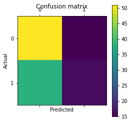

```python
import pylab as plt
%matplotlib inline
plt.matshow(knncm)
plt.title('Confusion matrix')
plt.colorbar()
plt.ylabel('Actual')
plt.xlabel('Predicted')
plt.show()
```

### 6 Neighbors

```python
n_neighbors = 6

knnclf = neighbors.KNeighborsClassifier(n_neighbors, weights='distance')
knnclf.fit(bt_train_norm, bt_target_train)
knnpreds_test = knnclf.predict(bt_test_norm)
print(classification_report(bt_target_test, knnpreds_test))
knncm = confusion_matrix(bt_target_test, knnpreds_test)
print (knncm)
print (knnclf.score(bt_train_norm, bt_target_train))
print (knnclf.score(bt_test_norm, bt_target_test))
```

```
              precision    recall  f1-score   support

          NO       0.61      0.68      0.64        66
         YES       0.54      0.46      0.50        54

    accuracy                           0.58       120
   macro avg       0.58      0.57      0.57       120
weighted avg       0.58      0.58      0.58       120

[[45 21]
 [29 25]]
1.0
0.5833333333333334
```

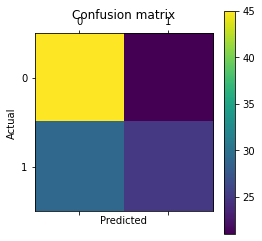

```python
import pylab as plt
%matplotlib inline
plt.matshow(knncm)
plt.title('Confusion matrix')
plt.colorbar()
plt.ylabel('Actual')
plt.xlabel('Predicted')
plt.show()
```

### 6 Neighbors, no weights

```python
n_neighbors = 6

knnclf = neighbors.KNeighborsClassifier(n_neighbors)
knnclf.fit(bt_train_norm, bt_target_train)
knnpreds_test = knnclf.predict(bt_test_norm)
print(classification_report(bt_target_test, knnpreds_test))
knncm = confusion_matrix(bt_target_test, knnpreds_test)
print (knncm)
print (knnclf.score(bt_train_norm, bt_target_train))
print (knnclf.score(bt_test_norm, bt_target_test))
```

```
              precision    recall  f1-score   support

          NO       0.60      0.76      0.67        66
         YES       0.56      0.37      0.44        54

    accuracy                           0.58       120
   macro avg       0.58      0.56      0.56       120
weighted avg       0.58      0.58      0.57       120

[[50 16]
 [34 20]]
0.70625
0.5833333333333334
```

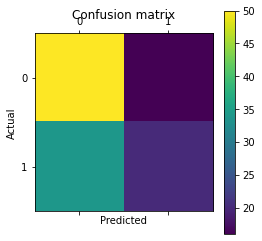

```python
import pylab as plt
%matplotlib inline
plt.matshow(knncm)
plt.title('Confusion matrix')
plt.colorbar()
plt.ylabel('Actual')
plt.xlabel('Predicted')
plt.show()
```

### 7 Neighbors

```python
n_neighbors = 7

knnclf = neighbors.KNeighborsClassifier(n_neighbors, weights='distance')
knnclf.fit(bt_train_norm, bt_target_train)
knnpreds_test = knnclf.predict(bt_test_norm)
print(classification_report(bt_target_test, knnpreds_test))
knncm = confusion_matrix(bt_target_test, knnpreds_test)
print (knncm)
print (knnclf.score(bt_train_norm, bt_target_train))
print (knnclf.score(bt_test_norm, bt_target_test))
```

```
              precision    recall  f1-score   support

          NO       0.61      0.70      0.65        66
         YES       0.56      0.46      0.51        54

    accuracy                           0.59       120
   macro avg       0.58      0.58      0.58       120
weighted avg       0.59      0.59      0.59       120

[[46 20]
 [29 25]]
1.0
0.5916666666666667
```

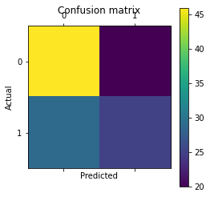

```python
import pylab as plt
%matplotlib inline
plt.matshow(knncm)
plt.title('Confusion matrix')
plt.colorbar()
plt.ylabel('Actual')
plt.xlabel('Predicted')
plt.show()
```

### 7 neighbors, no weights

```python
n_neighbors = 7

knnclf = neighbors.KNeighborsClassifier(n_neighbors)
knnclf.fit(bt_train_norm, bt_target_train)
knnpreds_test = knnclf.predict(bt_test_norm)
print(classification_report(bt_target_test, knnpreds_test))
knncm = confusion_matrix(bt_target_test, knnpreds_test)
print (knncm)
print (knnclf.score(bt_train_norm, bt_target_train))
print (knnclf.score(bt_test_norm, bt_target_test))
```

```
              precision    recall  f1-score   support

          NO       0.62      0.68      0.65        66
         YES       0.55      0.48      0.51        54

    accuracy                           0.59       120
   macro avg       0.58      0.58      0.58       120
weighted avg       0.59      0.59      0.59       120

[[45 21]
 [28 26]]
0.7020833333333333
0.5916666666666667
```

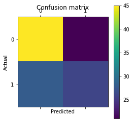

```python
import pylab as plt
%matplotlib inline
plt.matshow(knncm)
plt.title('Confusion matrix')
plt.colorbar()
plt.ylabel('Actual')
plt.xlabel('Predicted')
plt.show()
```

### 8 Neighbors

```python
n_neighbors = 8

knnclf = neighbors.KNeighborsClassifier(n_neighbors, weights='distance')
knnclf.fit(bt_train_norm, bt_target_train)
knnpreds_test = knnclf.predict(bt_test_norm)
print(classification_report(bt_target_test, knnpreds_test))
knncm = confusion_matrix(bt_target_test, knnpreds_test)
print (knncm)
print (knnclf.score(bt_train_norm, bt_target_train))
print (knnclf.score(bt_test_norm, bt_target_test))
```

```
              precision    recall  f1-score   support

          NO       0.61      0.70      0.65        66
         YES       0.55      0.44      0.49        54

    accuracy                           0.58       120
   macro avg       0.58      0.57      0.57       120
weighted avg       0.58      0.58      0.58       120

[[46 20]
 [30 24]]
1.0
0.5833333333333334
```

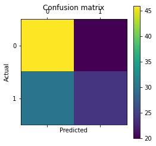

```python
import pylab as plt
%matplotlib inline
plt.matshow(knncm)
plt.title('Confusion matrix')
plt.colorbar()
plt.ylabel('Actual')
plt.xlabel('Predicted')
plt.show()
```

### 8 neighbors, no weights

```python
n_neighbors = 8

knnclf = neighbors.KNeighborsClassifier(n_neighbors)
knnclf.fit(bt_train_norm, bt_target_train)
knnpreds_test = knnclf.predict(bt_test_norm)
print(classification_report(bt_target_test, knnpreds_test))
knncm = confusion_matrix(bt_target_test, knnpreds_test)
print (knncm)
print (knnclf.score(bt_train_norm, bt_target_train))
print (knnclf.score(bt_test_norm, bt_target_test))
```

```
              precision    recall  f1-score   support

          NO       0.60      0.79      0.68        66
         YES       0.58      0.35      0.44        54

    accuracy                           0.59       120
   macro avg       0.59      0.57      0.56       120
weighted avg       0.59      0.59      0.57       120

[[52 14]
 [35 19]]
0.6875
0.5916666666666667
```

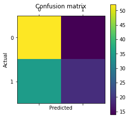

```python
import pylab as plt
%matplotlib inline
plt.matshow(knncm)
plt.title('Confusion matrix')
plt.colorbar()
plt.ylabel('Actual')
plt.xlabel('Predicted')
plt.show()
```

### 9 Neighbors

```python
n_neighbors = 9

knnclf = neighbors.KNeighborsClassifier(n_neighbors, weights='distance')
knnclf.fit(bt_train_norm, bt_target_train)
knnpreds_test = knnclf.predict(bt_test_norm)
print(classification_report(bt_target_test, knnpreds_test))
knncm = confusion_matrix(bt_target_test, knnpreds_test)
print (knncm)
print (knnclf.score(bt_train_norm, bt_target_train))
print (knnclf.score(bt_test_norm, bt_target_test))
```

```
              precision    recall  f1-score   support

          NO       0.61      0.70      0.65        66
         YES       0.55      0.44      0.49        54

    accuracy                           0.58       120
   macro avg       0.58      0.57      0.57       120
weighted avg       0.58      0.58      0.58       120

[[46 20]
 [30 24]]
1.0
0.5833333333333334
```

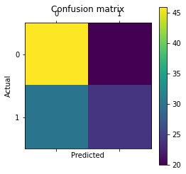

```python
import pylab as plt
%matplotlib inline
plt.matshow(knncm)
plt.title('Confusion matrix')
plt.colorbar()
plt.ylabel('Actual')
plt.xlabel('Predicted')
plt.show()
```

### 9 neighbors, no weights

```python
n_neighbors = 9

knnclf = neighbors.KNeighborsClassifier(n_neighbors)
knnclf.fit(bt_train_norm, bt_target_train)
knnpreds_test = knnclf.predict(bt_test_norm)
print(classification_report(bt_target_test, knnpreds_test))
knncm = confusion_matrix(bt_target_test, knnpreds_test)
print (knncm)
print (knnclf.score(bt_train_norm, bt_target_train))
print (knnclf.score(bt_test_norm, bt_target_test))
```

```
              precision    recall  f1-score   support

          NO       0.62      0.73      0.67        66
         YES       0.58      0.46      0.52        54

    accuracy                           0.61       120
   macro avg       0.60      0.60      0.59       120
weighted avg       0.60      0.61      0.60       120

[[48 18]
 [29 25]]
0.6916666666666667
0.6083333333333333
```

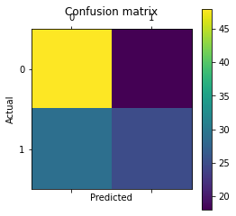

```python
import pylab as plt
%matplotlib inline
plt.matshow(knncm)
plt.title('Confusion matrix')
plt.colorbar()
plt.ylabel('Actual')
plt.xlabel('Predicted')
plt.show()
```

### 10 Neighbors

```python
n_neighbors = 10

knnclf = neighbors.KNeighborsClassifier(n_neighbors, weights='distance')
knnclf.fit(bt_train_norm, bt_target_train)
knnpreds_test = knnclf.predict(bt_test_norm)
print(classification_report(bt_target_test, knnpreds_test))
knncm = confusion_matrix(bt_target_test, knnpreds_test)
print (knncm)
print (knnclf.score(bt_train_norm, bt_target_train))
print (knnclf.score(bt_test_norm, bt_target_test))
```

```
              precision    recall  f1-score   support

          NO       0.59      0.68      0.63        66
         YES       0.52      0.43      0.47        54

    accuracy                           0.57       120
   macro avg       0.56      0.55      0.55       120
weighted avg       0.56      0.57      0.56       120

[[45 21]
 [31 23]]
1.0
0.5666666666666667
```

```python
import pylab as plt
%matplotlib inline
plt.matshow(knncm)
plt.title('Confusion matrix')
plt.colorbar()
plt.ylabel('Actual')
plt.xlabel('Predicted')
plt.show()
```

[output not shown]

### 10 neighbors, no weights

```
              precision    recall  f1-score   support

          NO       0.64      0.82      0.72        66
         YES       0.67      0.44      0.53        54

    accuracy                           0.65       120
   macro avg       0.65      0.63      0.63       120
weighted avg       0.65      0.65      0.64       120

[[54 12]
 [30 24]]
0.6833333333333333
0.65
```

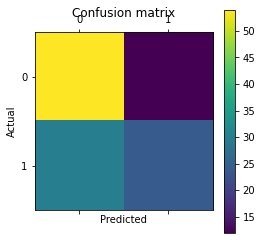

```python
n_neighbors = 10

knnclf = neighbors.KNeighborsClassifier(n_neighbors)
knnclf.fit(bt_train_norm, bt_target_train)
knnpreds_test = knnclf.predict(bt_test_norm)
print(classification_report(bt_target_test, knnpreds_test))
knncm = confusion_matrix(bt_target_test, knnpreds_test)
print (knncm)
print (knnclf.score(bt_train_norm, bt_target_train))
print (knnclf.score(bt_test_norm, bt_target_test))

import pylab as plt
%matplotlib inline
plt.matshow(knncm)
plt.title('Confusion matrix')
plt.colorbar()
plt.ylabel('Actual')
plt.xlabel('Predicted')
plt.show()
```

### 11 Neighbors

```python
n_neighbors = 11

knnclf = neighbors.KNeighborsClassifier(n_neighbors, weights='distance')
knnclf.fit(bt_train_norm, bt_target_train)
knnpreds_test = knnclf.predict(bt_test_norm)
print(classification_report(bt_target_test, knnpreds_test))
knncm = confusion_matrix(bt_target_test, knnpreds_test)
print (knncm)
print (knnclf.score(bt_train_norm, bt_target_train))
print (knnclf.score(bt_test_norm, bt_target_test))
```

```
              precision    recall  f1-score   support

          NO       0.61      0.71      0.66        66
         YES       0.56      0.44      0.49        54

    accuracy                           0.59       120
   macro avg       0.58      0.58      0.58       120
weighted avg       0.59      0.59      0.58       120

[[47 19]
 [30 24]]
1.0
0.5916666666666667
```

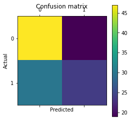

```python
import pylab as plt
%matplotlib inline
plt.matshow(knncm)
plt.title('Confusion matrix')
plt.colorbar()
plt.ylabel('Actual')
plt.xlabel('Predicted')
plt.show()
```

### 11 neighbors, no weights

```
              precision    recall  f1-score   support

          NO       0.63      0.74      0.68        66
         YES       0.60      0.46      0.52        54

    accuracy                           0.62       120
   macro avg       0.61      0.60      0.60       120
weighted avg       0.61      0.62      0.61       120

[[49 17]
 [29 25]]
0.68125
0.6166666666666667
```

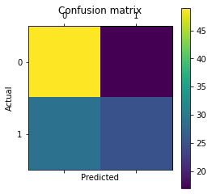

```python
n_neighbors = 11

knnclf = neighbors.KNeighborsClassifier(n_neighbors)
knnclf.fit(bt_train_norm, bt_target_train)
knnpreds_test = knnclf.predict(bt_test_norm)
print(classification_report(bt_target_test, knnpreds_test))
knncm = confusion_matrix(bt_target_test, knnpreds_test)
print (knncm)
print (knnclf.score(bt_train_norm, bt_target_train))
print (knnclf.score(bt_test_norm, bt_target_test))

import pylab as plt
%matplotlib inline
plt.matshow(knncm)
plt.title('Confusion matrix')
plt.colorbar()
plt.ylabel('Actual')
plt.xlabel('Predicted')
plt.show()
```

### 12 Neighbors

```python
n_neighbors = 12

knnclf = neighbors.KNeighborsClassifier(n_neighbors, weights='distance')
knnclf.fit(bt_train_norm, bt_target_train)
knnpreds_test = knnclf.predict(bt_test_norm)
print(classification_report(bt_target_test, knnpreds_test))
knncm = confusion_matrix(bt_target_test, knnpreds_test)
print (knncm)
print (knnclf.score(bt_train_norm, bt_target_train))
print (knnclf.score(bt_test_norm, bt_target_test))
```

```
              precision    recall  f1-score   support

          NO       0.62      0.71      0.66        66
         YES       0.57      0.46      0.51        54

    accuracy                           0.60       120
   macro avg       0.59      0.59      0.59       120
weighted avg       0.60      0.60      0.59       120

[[47 19]
 [29 25]]
1.0
0.6
```

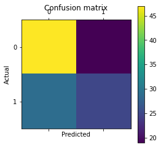

```python
import pylab as plt
%matplotlib inline
plt.matshow(knncm)
plt.title('Confusion matrix')
plt.colorbar()
plt.ylabel('Actual')
plt.xlabel('Predicted')
plt.show()
```

### 12 neighbors, no weights

```
              precision    recall  f1-score   support

          NO       0.62      0.82      0.71        66
         YES       0.64      0.39      0.48        54

    accuracy                           0.62       120
   macro avg       0.63      0.60      0.59       120
weighted avg       0.63      0.62      0.61       120

[[54 12]
 [33 21]]
0.65
0.625
```

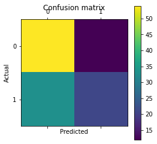

```python
n_neighbors = 12

knnclf = neighbors.KNeighborsClassifier(n_neighbors)
knnclf.fit(bt_train_norm, bt_target_train)
knnpreds_test = knnclf.predict(bt_test_norm)
print(classification_report(bt_target_test, knnpreds_test))
knncm = confusion_matrix(bt_target_test, knnpreds_test)
print (knncm)
print (knnclf.score(bt_train_norm, bt_target_train))
print (knnclf.score(bt_test_norm, bt_target_test))

import pylab as plt
%matplotlib inline
plt.matshow(knncm)
plt.title('Confusion matrix')
plt.colorbar()
plt.ylabel('Actual')
plt.xlabel('Predicted')
plt.show()
```

### 13 Neighbors

```python
n_neighbors = 13

knnclf = neighbors.KNeighborsClassifier(n_neighbors, weights='distance')
knnclf.fit(bt_train_norm, bt_target_train)
knnpreds_test = knnclf.predict(bt_test_norm)
print(classification_report(bt_target_test, knnpreds_test))
knncm = confusion_matrix(bt_target_test, knnpreds_test)
print (knncm)
print (knnclf.score(bt_train_norm, bt_target_train))
print (knnclf.score(bt_test_norm, bt_target_test))
```

```
              precision    recall  f1-score   support

          NO       0.64      0.73      0.68        66
         YES       0.60      0.50      0.55        54

    accuracy                           0.62       120
   macro avg       0.62      0.61      0.61       120
weighted avg       0.62      0.62      0.62       120

[[48 18]
 [27 27]]
1.0
0.625
```

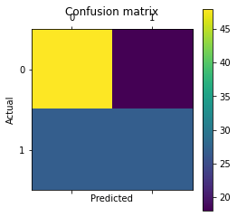

```python
import pylab as plt
%matplotlib inline
plt.matshow(knncm)
plt.title('Confusion matrix')
plt.colorbar()
plt.ylabel('Actual')
plt.xlabel('Predicted')
plt.show()
```

### 13 neighbors, no weights

```
              precision    recall  f1-score   support

          NO       0.63      0.77      0.69        66
         YES       0.62      0.44      0.52        54

    accuracy                           0.62       120
   macro avg       0.62      0.61      0.61       120
weighted avg       0.62      0.62      0.61       120

[[51 15]
 [30 24]]
0.6708333333333333
0.625
```

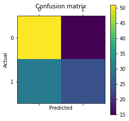

```python
n_neighbors = 13

knnclf = neighbors.KNeighborsClassifier(n_neighbors)
knnclf.fit(bt_train_norm, bt_target_train)
knnpreds_test = knnclf.predict(bt_test_norm)
print(classification_report(bt_target_test, knnpreds_test))
knncm = confusion_matrix(bt_target_test, knnpreds_test)
print (knncm)
print (knnclf.score(bt_train_norm, bt_target_train))
print (knnclf.score(bt_test_norm, bt_target_test))

import pylab as plt
%matplotlib inline
plt.matshow(knncm)
plt.title('Confusion matrix')
plt.colorbar()
plt.ylabel('Actual')
plt.xlabel('Predicted')
plt.show()
```

### 14 Neighbors

```python
n_neighbors = 14

knnclf = neighbors.KNeighborsClassifier(n_neighbors, weights='distance')
knnclf.fit(bt_train_norm, bt_target_train)
knnpreds_test = knnclf.predict(bt_test_norm)
print(classification_report(bt_target_test, knnpreds_test))
knncm = confusion_matrix(bt_target_test, knnpreds_test)
print (knncm)
print (knnclf.score(bt_train_norm, bt_target_train))
print (knnclf.score(bt_test_norm, bt_target_test))
```

```
              precision    recall  f1-score   support

          NO       0.61      0.71      0.66        66
         YES       0.56      0.44      0.49        54

    accuracy                           0.59       120
   macro avg       0.58      0.58      0.58       120
weighted avg       0.59      0.59      0.58       120

[[47 19]
 [30 24]]
1.0
0.5916666666666667
```

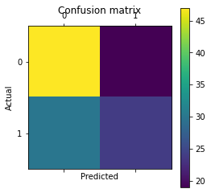

```python
import pylab as plt
%matplotlib inline
plt.matshow(knncm)
plt.title('Confusion matrix')
plt.colorbar()
plt.ylabel('Actual')
plt.xlabel('Predicted')
plt.show()
```

### 14 neighbors, no weights

```
              precision    recall  f1-score   support

          NO       0.61      0.82      0.70        66
         YES       0.62      0.37      0.47        54

    accuracy                           0.62       120
   macro avg       0.62      0.59      0.58       120
weighted avg       0.62      0.62      0.60       120

[[54 12]
 [34 20]]
0.6604166666666667
0.6166666666666667
```

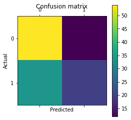

```python
n_neighbors = 14

knnclf = neighbors.KNeighborsClassifier(n_neighbors)
knnclf.fit(bt_train_norm, bt_target_train)
knnpreds_test = knnclf.predict(bt_test_norm)
print(classification_report(bt_target_test, knnpreds_test))
knncm = confusion_matrix(bt_target_test, knnpreds_test)
print (knncm)
print (knnclf.score(bt_train_norm, bt_target_train))
print (knnclf.score(bt_test_norm, bt_target_test))

import pylab as plt
%matplotlib inline
plt.matshow(knncm)
plt.title('Confusion matrix')
plt.colorbar()
plt.ylabel('Actual')
plt.xlabel('Predicted')
plt.show()
```

### 15 Neighbors

```python
n_neighbors = 15

knnclf = neighbors.KNeighborsClassifier(n_neighbors, weights='distance')
knnclf.fit(bt_train_norm, bt_target_train)
knnpreds_test = knnclf.predict(bt_test_norm)
print(classification_report(bt_target_test, knnpreds_test))
knncm = confusion_matrix(bt_target_test, knnpreds_test)
print (knncm)
print (knnclf.score(bt_train_norm, bt_target_train))
print (knnclf.score(bt_test_norm, bt_target_test))
```

```
              precision    recall  f1-score   support

          NO       0.62      0.70      0.66        66
         YES       0.57      0.48      0.52        54

    accuracy                           0.60       120
   macro avg       0.59      0.59      0.59       120
weighted avg       0.60      0.60      0.60       120

[[46 20]
 [28 26]]
1.0
0.6
```

```python
import pylab as plt
%matplotlib inline
plt.matshow(knncm)
plt.title('Confusion matrix')
plt.colorbar()
plt.ylabel('Actual')
plt.xlabel('Predicted')
plt.show()
```

[output not shown]

### 15 neighbors, no weights

```
              precision    recall  f1-score   support

          NO       0.63      0.76      0.69        66
         YES       0.61      0.46      0.53        54

    accuracy                           0.62       120
   macro avg       0.62      0.61      0.61       120
weighted avg       0.62      0.62      0.62       120

[[50 16]
 [29 25]]
0.65
0.625
```

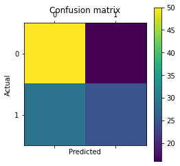

```python
n_neighbors = 15

knnclf = neighbors.KNeighborsClassifier(n_neighbors)
knnclf.fit(bt_train_norm, bt_target_train)
knnpreds_test = knnclf.predict(bt_test_norm)
print(classification_report(bt_target_test, knnpreds_test))
knncm = confusion_matrix(bt_target_test, knnpreds_test)
print (knncm)
print (knnclf.score(bt_train_norm, bt_target_train))
print (knnclf.score(bt_test_norm, bt_target_test))

import pylab as plt
%matplotlib inline
plt.matshow(knncm)
plt.title('Confusion matrix')
plt.colorbar()
plt.ylabel('Actual')
plt.xlabel('Predicted')
plt.show()
```

### 16 Neighbors

```python
n_neighbors = 16

knnclf = neighbors.KNeighborsClassifier(n_neighbors, weights='distance')
knnclf.fit(bt_train_norm, bt_target_train)
knnpreds_test = knnclf.predict(bt_test_norm)
print(classification_report(bt_target_test, knnpreds_test))
knncm = confusion_matrix(bt_target_test, knnpreds_test)
print (knncm)
print (knnclf.score(bt_train_norm, bt_target_train))
print (knnclf.score(bt_test_norm, bt_target_test))
```

```
              precision    recall  f1-score   support

          NO       0.63      0.71      0.67        66
         YES       0.58      0.48      0.53        54

    accuracy                           0.61       120
   macro avg       0.60      0.60      0.60       120
weighted avg       0.60      0.61      0.60       120

[[47 19]
 [28 26]]
1.0
0.6083333333333333
```

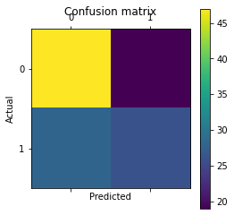

```python
import pylab as plt
%matplotlib inline
plt.matshow(knncm)
plt.title('Confusion matrix')
plt.colorbar()
plt.ylabel('Actual')
plt.xlabel('Predicted')
plt.show()
```

### 16 neighbors, no weights

```
              precision    recall  f1-score   support

          NO       0.64      0.82      0.72        66
         YES       0.66      0.43      0.52        54

    accuracy                           0.64       120
   macro avg       0.65      0.62      0.62       120
weighted avg       0.65      0.64      0.63       120

[[54 12]
 [31 23]]
0.6625
0.6416666666666667
```

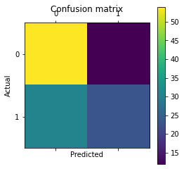

```python
n_neighbors = 16

knnclf = neighbors.KNeighborsClassifier(n_neighbors)
knnclf.fit(bt_train_norm, bt_target_train)
knnpreds_test = knnclf.predict(bt_test_norm)
print(classification_report(bt_target_test, knnpreds_test))
knncm = confusion_matrix(bt_target_test, knnpreds_test)
print (knncm)
print (knnclf.score(bt_train_norm, bt_target_train))
print (knnclf.score(bt_test_norm, bt_target_test))

import pylab as plt
%matplotlib inline
plt.matshow(knncm)
plt.title('Confusion matrix')
plt.colorbar()
plt.ylabel('Actual')
plt.xlabel('Predicted')
plt.show()
```

### 17 Neighbors

```python
n_neighbors = 17

knnclf = neighbors.KNeighborsClassifier(n_neighbors, weights='distance')
knnclf.fit(bt_train_norm, bt_target_train)
knnpreds_test = knnclf.predict(bt_test_norm)
print(classification_report(bt_target_test, knnpreds_test))
knncm = confusion_matrix(bt_target_test, knnpreds_test)
print (knncm)
print (knnclf.score(bt_train_norm, bt_target_train))
print (knnclf.score(bt_test_norm, bt_target_test))
```

```
              precision    recall  f1-score   support

          NO       0.62      0.70      0.66        66
         YES       0.57      0.48      0.52        54

    accuracy                           0.60       120
   macro avg       0.59      0.59      0.59       120
weighted avg       0.60      0.60      0.60       120

[[46 20]
 [28 26]]
1.0
0.6
```

```python
import pylab as plt
%matplotlib inline
plt.matshow(knncm)
plt.title('Confusion matrix')
plt.colorbar()
plt.ylabel('Actual')
plt.xlabel('Predicted')
plt.show()
```

[output not shown]

### 17 neighbors, no weights

```
              precision    recall  f1-score   support

          NO       0.66      0.82      0.73        66
         YES       0.68      0.48      0.57        54

    accuracy                           0.67       120
   macro avg       0.67      0.65      0.65       120
weighted avg       0.67      0.67      0.66       120

[[54 12]
 [28 26]]
0.6520833333333333
0.6666666666666666
```

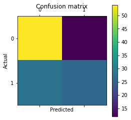

```python
n_neighbors = 17

knnclf = neighbors.KNeighborsClassifier(n_neighbors)
knnclf.fit(bt_train_norm, bt_target_train)
knnpreds_test = knnclf.predict(bt_test_norm)
print(classification_report(bt_target_test, knnpreds_test))
knncm = confusion_matrix(bt_target_test, knnpreds_test)
print (knncm)
print (knnclf.score(bt_train_norm, bt_target_train))
print (knnclf.score(bt_test_norm, bt_target_test))

import pylab as plt
%matplotlib inline
plt.matshow(knncm)
plt.title('Confusion matrix')
plt.colorbar()
plt.ylabel('Actual')
plt.xlabel('Predicted')
plt.show()
```

### 18 Neighbors

```python
n_neighbors = 18

knnclf = neighbors.KNeighborsClassifier(n_neighbors, weights='distance')
knnclf.fit(bt_train_norm, bt_target_train)
knnpreds_test = knnclf.predict(bt_test_norm)
print(classification_report(bt_target_test, knnpreds_test))
knncm = confusion_matrix(bt_target_test, knnpreds_test)
print (knncm)
print (knnclf.score(bt_train_norm, bt_target_train))
print (knnclf.score(bt_test_norm, bt_target_test))
```

```
              precision    recall  f1-score   support

          NO       0.64      0.71      0.67        66
         YES       0.59      0.50      0.54        54

    accuracy                           0.62       120
   macro avg       0.61      0.61      0.61       120
weighted avg       0.61      0.62      0.61       120

[[47 19]
 [27 27]]
1.0
0.6166666666666667
```

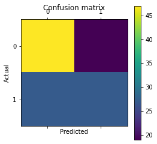

```python
import pylab as plt
%matplotlib inline
plt.matshow(knncm)
plt.title('Confusion matrix')
plt.colorbar()
plt.ylabel('Actual')
plt.xlabel('Predicted')
plt.show()
```

### 18 neighbors, no weights

```
              precision    recall  f1-score   support

          NO       0.66      0.86      0.75        66
         YES       0.73      0.44      0.55        54

    accuracy                           0.68       120
   macro avg       0.69      0.65      0.65       120
weighted avg       0.69      0.68      0.66       120

[[57  9]
 [30 24]]
0.6416666666666667
0.675
```

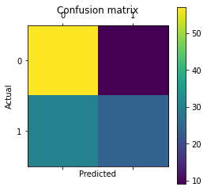

```python
n_neighbors = 18

knnclf = neighbors.KNeighborsClassifier(n_neighbors)
knnclf.fit(bt_train_norm, bt_target_train)
knnpreds_test = knnclf.predict(bt_test_norm)
print(classification_report(bt_target_test, knnpreds_test))
knncm = confusion_matrix(bt_target_test, knnpreds_test)
print (knncm)
print (knnclf.score(bt_train_norm, bt_target_train))
print (knnclf.score(bt_test_norm, bt_target_test))

import pylab as plt
%matplotlib inline
plt.matshow(knncm)
plt.title('Confusion matrix')
plt.colorbar()
plt.ylabel('Actual')
plt.xlabel('Predicted')
plt.show()
```

### 19 Neighbors

```python
n_neighbors = 19

knnclf = neighbors.KNeighborsClassifier(n_neighbors, weights='distance')
knnclf.fit(bt_train_norm, bt_target_train)
knnpreds_test = knnclf.predict(bt_test_norm)
print(classification_report(bt_target_test, knnpreds_test))
knncm = confusion_matrix(bt_target_test, knnpreds_test)
print (knncm)
print (knnclf.score(bt_train_norm, bt_target_train))
print (knnclf.score(bt_test_norm, bt_target_test))
```

```
              precision    recall  f1-score   support

          NO       0.63      0.73      0.68        66
         YES       0.59      0.48      0.53        54

    accuracy                           0.62       120
   macro avg       0.61      0.60      0.60       120
weighted avg       0.61      0.62      0.61       120

[[48 18]
 [28 26]]
1.0
0.6166666666666667
```

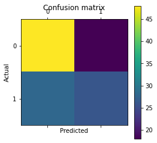

```python
import pylab as plt
%matplotlib inline
plt.matshow(knncm)
plt.title('Confusion matrix')
plt.colorbar()
plt.ylabel('Actual')
plt.xlabel('Predicted')
plt.show()
```

### 19 neighbors, no weights

```
              precision    recall  f1-score   support

          NO       0.65      0.83      0.73        66
         YES       0.69      0.46      0.56        54

    accuracy                           0.67       120
   macro avg       0.67      0.65      0.64       120
weighted avg       0.67      0.67      0.65       120

[[55 11]
 [29 25]]
0.65
0.6666666666666666
```

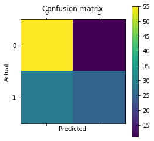

```python
n_neighbors = 19

knnclf = neighbors.KNeighborsClassifier(n_neighbors)
knnclf.fit(bt_train_norm, bt_target_train)
knnpreds_test = knnclf.predict(bt_test_norm)
print(classification_report(bt_target_test, knnpreds_test))
knncm = confusion_matrix(bt_target_test, knnpreds_test)
print (knncm)
print (knnclf.score(bt_train_norm, bt_target_train))
print (knnclf.score(bt_test_norm, bt_target_test))

import pylab as plt
%matplotlib inline
plt.matshow(knncm)
plt.title('Confusion matrix')
plt.colorbar()
plt.ylabel('Actual')
plt.xlabel('Predicted')
plt.show()
```

### 20 Neighbors

```python
n_neighbors = 20

knnclf = neighbors.KNeighborsClassifier(n_neighbors, weights='distance')
knnclf.fit(bt_train_norm, bt_target_train)
knnpreds_test = knnclf.predict(bt_test_norm)
print(classification_report(bt_target_test, knnpreds_test))
knncm = confusion_matrix(bt_target_test, knnpreds_test)
print (knncm)
print (knnclf.score(bt_train_norm, bt_target_train))
print (knnclf.score(bt_test_norm, bt_target_test))
```

```
              precision    recall  f1-score   support

          NO       0.62      0.70      0.66        66
         YES       0.57      0.48      0.52        54

    accuracy                           0.60       120
   macro avg       0.59      0.59      0.59       120
weighted avg       0.60      0.60      0.60       120

[[46 20]
 [28 26]]
1.0
0.6
```

```python
import pylab as plt
%matplotlib inline
plt.matshow(knncm)
plt.title('Confusion matrix')
plt.colorbar()
plt.ylabel('Actual')
plt.xlabel('Predicted')
plt.show()
```

[output not shown]

### 20 neighbors, no weights

```
              precision    recall  f1-score   support

          NO       0.64      0.86      0.74        66
         YES       0.71      0.41      0.52        54

    accuracy                           0.66       120
   macro avg       0.68      0.64      0.63       120
weighted avg       0.67      0.66      0.64       120

[[57  9]
 [32 22]]
0.6416666666666667
0.6583333333333333
```

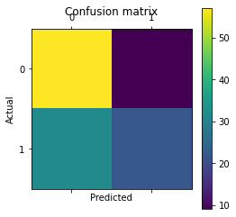

```python
n_neighbors = 20

knnclf = neighbors.KNeighborsClassifier(n_neighbors)
knnclf.fit(bt_train_norm, bt_target_train)
knnpreds_test = knnclf.predict(bt_test_norm)
print(classification_report(bt_target_test, knnpreds_test))
knncm = confusion_matrix(bt_target_test, knnpreds_test)
print (knncm)
print (knnclf.score(bt_train_norm, bt_target_train))
print (knnclf.score(bt_test_norm, bt_target_test))

import pylab as plt
%matplotlib inline
plt.matshow(knncm)
plt.title('Confusion matrix')
plt.colorbar()
plt.ylabel('Actual')
plt.xlabel('Predicted')
plt.show()
```

## Nearest Neighbor Analysis

#### The nearest neighbor classification found that when distances are weighted there is high variance within the model. This is shown through the high accuracy in the training dataset, but much lower accuracy in the testing set. When distances are not weighted, there is less accuracy in the training set, but there is a higher degree of accuracy in the testing set. The highest level of accuracy for classification on a testing set was with 18 neighbors and no weights, which found an accuracy level of 67%, while 18 neighbors with distances weighted found an accuracy of 62%.

### Part c

```python
from sklearn import tree, naive_bayes
```

```python
treeclf = tree.DecisionTreeClassifier(criterion='entropy', min_samples_split=3)
```

```python
treeclf = treeclf.fit(bt_train, bt_target_train)
```

```python
treepreds_test = treeclf.predict(bt_test)
print (treepreds_test)
```

```
['NO' 'YES' 'NO' 'NO' 'NO' 'NO' 'NO' 'NO' 'NO' 'YES' 'NO' 'YES' 'NO' 'NO' 'YES'
 'YES' 'YES' 'YES' 'YES' 'NO' 'YES' 'YES' 'YES' 'NO' 'NO' 'YES' 'YES' 'YES'
 'NO' 'YES' 'YES' 'NO' 'YES' 'NO' 'NO' 'NO' 'NO' 'YES' 'NO' 'NO' 'NO' 'YES'
 'YES' 'NO' 'YES' 'NO' 'NO' 'NO' 'NO' 'NO' 'NO' 'NO' 'NO' 'YES' 'YES' 'YES'
 'YES' 'NO' 'YES' 'NO' 'NO' 'NO' 'YES' 'NO' 'NO' 'NO' 'NO' 'NO' 'YES' 'NO' 'NO'
 'NO' 'YES' 'NO' 'NO' 'NO' 'NO' 'NO' 'NO' 'NO' 'NO' 'YES' 'NO' 'NO' 'YES' 'NO'
 'NO' 'NO' 'YES' 'YES' 'NO' 'YES' 'NO' 'NO' 'NO' 'NO' 'NO' 'NO' 'YES' 'YES'
 'YES' 'YES' 'NO' 'YES' 'NO' 'NO' 'YES' 'NO' 'YES' 'YES' 'YES' 'YES' 'YES'
 'YES' 'NO' 'NO' 'NO' 'YES' 'NO' 'YES']
```

```python
print (treeclf.score(bt_test, bt_target_test))
```

```
0.5333333333333333
```

```python
print (treeclf.score(bt_train, bt_target_train))
```

```
0.9791666666666666
```

```python
print(classification_report(bt_target_test, treepreds_test))
```

```
              precision    recall  f1-score   support

          NO       0.57      0.62      0.59        66
         YES       0.48      0.43      0.45        54

    accuracy                           0.53       120
   macro avg       0.52      0.52      0.52       120
weighted avg       0.53      0.53      0.53       120
```

```python
treecm = confusion_matrix(bt_target_test, treepreds_test, labels=['YES','NO'])
print (treecm)
```

```
[[23 31]
 [25 41]]
```

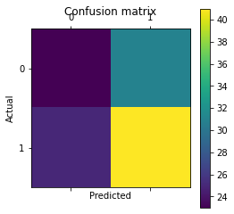

```python
import pylab as plt
%matplotlib inline
plt.matshow(treecm)
plt.title('Confusion matrix')
plt.colorbar()
plt.ylabel('Actual')
plt.xlabel('Predicted')
plt.show()
```

### Naive Bayes

```python
nbclf = naive_bayes.GaussianNB()
nbclf = nbclf.fit(bt_train, bt_target_train)
nbpreds_test = nbclf.predict(bt_test)
print (nbpreds_test)
```

```
['NO' 'YES' 'YES' 'YES' 'YES' 'NO' 'NO' 'NO' 'NO' 'YES' 'NO' 'YES' 'NO' 'NO'
 'NO' 'NO' 'YES' 'NO' 'YES' 'NO' 'YES' 'YES' 'NO' 'NO' 'NO' 'NO' 'YES' 'YES'
 'NO' 'YES' 'YES' 'NO' 'NO' 'NO' 'NO' 'NO' 'YES' 'NO' 'NO' 'NO' 'NO' 'NO' 'YES'
 'NO' 'YES' 'NO' 'NO' 'NO' 'NO' 'NO' 'YES' 'YES' 'NO' 'NO' 'NO' 'YES' 'YES'
 'NO' 'NO' 'YES' 'YES' 'NO' 'YES' 'NO' 'NO' 'NO' 'NO' 'NO' 'NO' 'YES' 'NO' 'NO'
 'NO' 'NO' 'NO' 'NO' 'NO' 'YES' 'YES' 'NO' 'NO' 'YES' 'NO' 'NO' 'NO' 'NO' 'NO'
 'NO' 'YES' 'NO' 'NO' 'YES' 'NO' 'NO' 'YES' 'NO' 'NO' 'YES' 'NO' 'NO' 'NO'
 'YES' 'NO' 'YES' 'NO' 'NO' 'YES' 'NO' 'YES' 'NO' 'NO' 'NO' 'NO' 'YES' 'NO'
 'NO' 'NO' 'NO' 'NO' 'NO']
```

```python
print (nbclf.score(bt_train, bt_target_train))
```

```
0.6145833333333334
```

```python
print (nbclf.score(bt_test, bt_target_test))
```

```
0.5916666666666667
```

```python
print(classification_report(bt_target_test, nbpreds_test))
```

```
              precision    recall  f1-score   support

          NO       0.60      0.76      0.67        66
         YES       0.57      0.39      0.46        54

    accuracy                           0.59       120
   macro avg       0.58      0.57      0.57       120
weighted avg       0.59      0.59      0.58       120
```

```python
NBcm = confusion_matrix(bt_target_test, nbpreds_test, labels=['YES', 'NO'])
print(NBcm)
```

```
[[21 33]
 [16 50]]
```

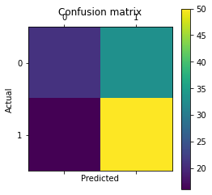

```python
import pylab as plt
%matplotlib inline
plt.matshow(NBcm)
plt.title('Confusion matrix')
plt.colorbar()
plt.ylabel('Actual')
plt.xlabel('Predicted')
plt.show()
```